# Using Machine Learning to Predict the Qualitative Execution of Weight Lifting Exercices

Xavier Nayrac

2015-09-27

# Abstract

It is demonstrated that the qualitative execution of weight lifting exercices can be predicted using machine learning. Two different algorithms will be tried. The first one, **recursive partitioning** won’t show us a good enough accuracy (about 75%). Contrary to the second one, **random forest**, that will show an accuracy of more than 99%. Finally, using five times less variables from the dataset (the most important ones), we will obtain the almost same accuracy of 99%, but five times faster.

# Introduction

This is a classification problem, so after cleaning the dataset I’m going to use a recursive partitioning algorithm (rpart). We will see that this algorithm is fast, but not very accurate for our problem. I will make a second try with the random forest algorithm, much slower but also much accurate for our problem. To stay reasonnably fast with the random forest algorithm, I will make use of parallelization. Both algorithms will be used with cross validation.

I will show that the accuracy of the random forest algorithm is almost perfect for our problem.

Finally, I will discuss the selection of the most important features only.

It should be noted that throughout this paper I will use the words *variable*, *feature* and *column* interchangeably.

# Methods

## The Dataset

The dataset used in this project comes from [HAR](http://groupware.les.inf.puc-rio.br/har).

```r
df <- read.csv('data/pml-training.csv', na.strings=c("NA", "#DIV/0!"))
```

There is 160 features for 19622 observations.

## Training and Cross Validation

Before doing anything else, I’m going to partition the dataset between a training set (60%) and a validation set (40%).

```r
inTrain <- createDataPartition(y=df$classe, p=.6, list=F)
training <- df[inTrain, ]
validation <- df[-inTrain, ]
```

The training set will be cleaned, but I will not touch at all to the validation set.

## Cleansing

I remove the first two features. One is simply the observation’s index and the other is the user’s name. None of them contribute to the `classe` of the exercices.

Next I remove all features with a variance near to zero. Those are features that doesn’t contribute enough (or even not at all) to the classification to be kept.

After that, I remove all features with NA values. I know this is a very drastic cleansing but, if the algorithm performs well the first time without those features, this will be a big win.

Finally, I remove the first four remaining features, as the authors of the study claim in their paper that those are not measurements.

It’s worth noting that the cleansing was surprisingly quick and easy.

```r
training <- training[, !grepl("X", names(training))]
training <- training[, !grepl("user_name", names(training))]
nzv <- nearZeroVar(training)
training <- training[, -nzv]
nas <- apply(training, 2, function(x) sum(is.na(x)) > 0)
training <- training[, !nas]
training <- training[, -(1:4)]
```

## Machine Learning Model

### Recursive Partitioning

First I use a recursive partitioning algorithm through the `rpart()` function of the *rpart* R package. The algorithm runs quickly, but is not very accurate for our problem (at least with default settings).

```r
fit0 <- rpart(classe ~ ., data=training, method="class")
prediction0 <- predict(fit0, validation, type="class")
accuracy0 <-sum(validation$classe == prediction0) / length(prediction0)
cat(accuracy0)
```

```
## 0.7392302
```

An accuracy of 0.7392302 is not good enough.

### Random Forest

I’m going to use the `randomForest()` function from the *randomForest* R package directly, because it is way faster than its *caret* wrapper. But to further reduce the time taken by the algorithm, I’m going to add some parallelization. I’m going to use 3 CPU cores, each of them computing 400 trees.

```r
cl <- makeCluster(3)
registerDoParallel(cl)
fit1 <- foreach(ntree=c(400, 400, 400),
                .combine=combine, .packages='randomForest') %dopar% {
    randomForest(classe ~ ., data=training, ntree=ntree, importance=T)
}
stopCluster(cl)
```

Now it’s time to validate the model on the validation set.

```r
prediction <- predict(fit1, validation, type="class")
```

# Results

With an accuracy of 0.7392302 and an expected out of sample error of 0.2607698 for the recursive partitioning algorithm it’s a fail.

But for the random forest algorithm it’s a win.

The accuracy of this model is 0.9924802 and so the expected out of sample error is 0.0075198. It’s a very accurate model to predict the qualitative execution of weight lifting exercices.

Results of both algorithms are summarized in the following table:

Comparison of both algorithms

|  | Recursive.partioning | Random.forest |
| --- | --- | --- |
| Accuracy | 0.739 | 0.992 |
| Out of sample error | 0.261 | 0.008 |

# Discussion

## An Almost Perfect Detection of Classe A

A subset table taken from the confusion matrix is showing us that the prediction on class A is almost perfect:

Subset for classe A

|  | Sensitivity | Specificity | Balanced Accuracy |
| --- | --- | --- | --- |
| Class: A | 1.000 | 0.998 | 0.999 |
| Class: B | 0.990 | 0.998 | 0.994 |
| Class: C | 0.989 | 0.996 | 0.992 |
| Class: D | 0.981 | 0.999 | 0.990 |
| Class: E | 0.997 | 1.000 | 0.998 |

## Using Fewer Variables

It’s worth noting that an reasonnably accurate model could be built with only 9 features instead of 52. This could be use to compute the fitted model faster.

Here I’m going to keep only the 9 most important variables to build a second model:

```r
t2 <- training[, c(1, 2, 3, 39, 38, 41, 19, 14, 40, 53)]
cl <- makeCluster(3)
registerDoParallel(cl)
fit2 <- foreach(ntree=c(400, 400, 400), .combine=combine, .packages='randomForest') %dopar% {
    randomForest(classe ~ ., data=t2, ntree=ntree, importance=T)
}
stopCluster(cl)
prediction2 <- predict(fit2, validation, type="class")
```

The accuracy of this «dimished» model is still pretty good:

```r
confusionMatrix(prediction2, validation$classe)[["overall"]][["Accuracy"]]
```

```
## [1] 0.9900586
```

As you can see, the two predictions are very close to each other:

Model with 52 features

| A | B | C | D | E |
| --- | --- | --- | --- | --- |
| 2231 | 10 | 0 | 0 | 0 |
| 0 | 1503 | 12 | 0 | 0 |
| 0 | 5 | 1353 | 22 | 2 |
| 1 | 0 | 3 | 1262 | 2 |
| 0 | 0 | 0 | 2 | 1438 |

Model with 9 features

| A | B | C | D | E |
| --- | --- | --- | --- | --- |
| 2229 | 12 | 1 | 0 | 0 |
| 1 | 1487 | 6 | 0 | 7 |
| 0 | 17 | 1352 | 11 | 5 |
| 2 | 1 | 9 | 1273 | 3 |
| 0 | 1 | 0 | 2 | 1427 |

# Conclusions

As expected, classifications algorithms works well on classification problem and the quality of weight lifting exercices can be predicted by machine learning.

On the one hand, we have seen that *rpart* algorithm is quick but its accuracy is not really good. Anyway it can be a good «first try».

On the other hand, the *random forest* algorithm performed very well on our carefully cleaned data. However, one should not hesitate to keep only a few features if time is a concern.

# References

[Qualitative activity recognition of weight lifting exercices](http://groupware.les.inf.puc-rio.br/work.jsf?p1=11201)

[Source code of this document](https://github.com/lkdjiin/c8)

# Appendix A

## Most Important Features

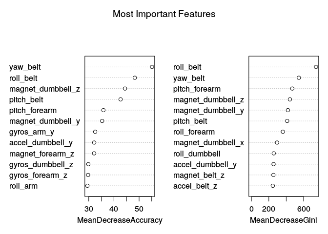

mean decrease accuracy and gini

# Appendix B

## Correlation Matrix

There is 1326 unique correlations. It could be useful to see it all in a plot.

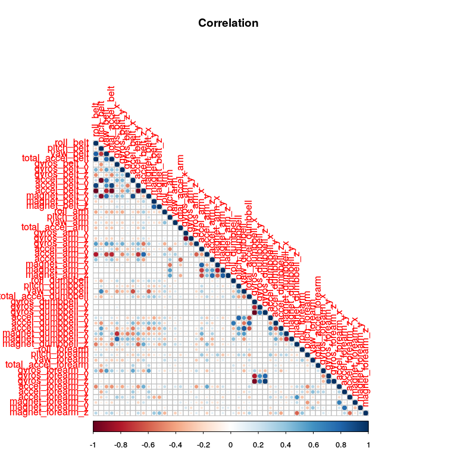

unique spearman’s r

# Appendix C

## Classes

Classes in the dataset are all on the same order of magnitude.

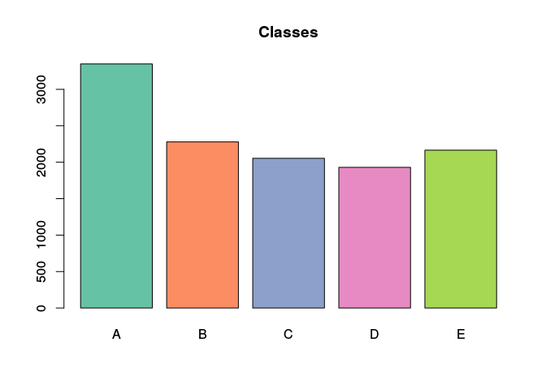

the five classes

# Appendix D

## Timing

First the timing of the recursive partitioning algorithm with 52 variables:

```r
system.time( fit0 <- rpart(classe ~ ., data=training, method="class") )
```

```
##    user  system elapsed
##   2.204   0.004   2.207
```

Then the timing of the random forest algorithm with 52 variables:

```r
system.time({
    cl <- makeCluster(3)
    registerDoParallel(cl)
    fit1 <- foreach(ntree=c(400, 400, 400),
                    .combine=combine, .packages='randomForest') %dopar% {
        randomForest(classe ~ ., data=training, ntree=ntree, importance=T)
    }
    stopCluster(cl)
})
```

```
##    user  system elapsed
##   1.404   0.184  86.132
```

Finally the timing of the random forest algorithm with 9 variables:

```r
system.time({
    cl <- makeCluster(3)
    registerDoParallel(cl)
    fit2 <- foreach(ntree=c(400, 400, 400),
                    .combine=combine, .packages='randomForest') %dopar% {
        randomForest(classe ~ ., data=t2, ntree=ntree, importance=T)
    }
    stopCluster(cl)
})
```

```
##    user  system elapsed
##   0.976   0.108  15.543
```

# Appendix E

## Confusion Matrix of the Best Model

This is the confusion matrix of the best model, that is the random forest algorithm on 52 features.

```r
confusionMatrix(prediction, validation$classe)
```

```
## Confusion Matrix and Statistics
##
##           Reference
## Prediction    A    B    C    D    E
##          A 2231   10    0    0    0
##          B    0 1503   12    0    0
##          C    0    5 1353   22    2
##          D    1    0    3 1262    2
##          E    0    0    0    2 1438
##
## Overall Statistics
##
##                Accuracy : 0.9925
##                  95% CI : (0.9903, 0.9943)
##     No Information Rate : 0.2845
##     P-Value [Acc > NIR] : < 2.2e-16
##
##                   Kappa : 0.9905
##  Mcnemar's Test P-Value : NA
##
## Statistics by Class:
##
##                      Class: A Class: B Class: C Class: D Class: E
## Sensitivity            0.9996   0.9901   0.9890   0.9813   0.9972
## Specificity            0.9982   0.9981   0.9955   0.9991   0.9997
## Pos Pred Value         0.9955   0.9921   0.9790   0.9953   0.9986
## Neg Pred Value         0.9998   0.9976   0.9977   0.9964   0.9994
## Prevalence             0.2845   0.1935   0.1744   0.1639   0.1838
## Detection Rate         0.2843   0.1916   0.1724   0.1608   0.1833
## Detection Prevalence   0.2856   0.1931   0.1761   0.1616   0.1835
## Balanced Accuracy      0.9989   0.9941   0.9923   0.9902   0.9985
```